# Inferential Statistics Course Project

j-ros

## Exponential distribution: simultion analysis

### Introduction

In this section we are going to explore the statistical properties of the exponential distribution via averages of 40 exponentials. We will do 1000 simulations and compare the results with the theoretical expected ones.

### Setup

The code below simulates 1000 instances of 40 exponential distributions with rate parameter 0.2. It also reports the mean and variance of the simulated distribution.

```r
lambda<-0.2
n<-1000
m<-40
simRes<-array(rexp(n*m,lambda),c(n,m))
simMean<-apply(simRes,1,mean)
simVar<-apply(simRes,1,var)
sm<-mean(simMean); sv<-mean(simVar)
```

We can see that the sample mean 4.9930941 approaches the theoretical result of 1/lambda = 5 and that the sample variance 24.9540135 approaches the theoretical values of (1/lambda)^2 = 25, as per the Law of Large Numbers.

### Analysis

Now that we have our simulated distribution and parameters computed, we are going to show that the distribution resulting from simulations approaches a Gaussian one as stated by the Central Limit Theorem.

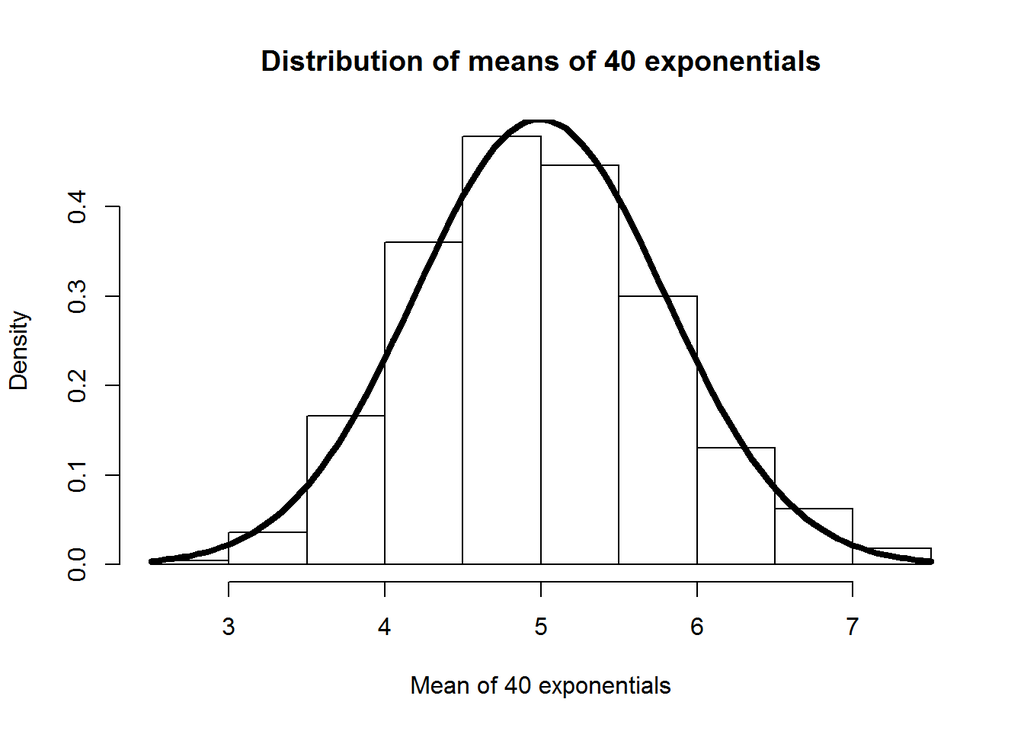

```r
hist(simMean,main="Distribution of means of 40 exponentials",probability=T,
     xlab="Mean of 40 exponentials")
curve(dnorm(x,mean=mean(simMean),sd=sd(simMean)),add=T,lwd=4)
```

## Basic Inferential Data Analysis

### Introduction

In this section we are going to perform basic inferential data analysis on the ToothGrowth dataset. First we explore the variables present and convert the dose to factor. Then plot the len variable depending on supp and dose.

```r
str(ToothGrowth)
```

```
## 'data.frame':    60 obs. of  3 variables:
##  $ len : num  4.2 11.5 7.3 5.8 6.4 10 11.2 11.2 5.2 7 ...
##  $ supp: Factor w/ 2 levels "OJ","VC": 2 2 2 2 2 2 2 2 2 2 ...
##  $ dose: num  0.5 0.5 0.5 0.5 0.5 0.5 0.5 0.5 0.5 0.5 ...
```

```r
summary(ToothGrowth)
```

```
##       len        supp         dose
##  Min.   : 4.20   OJ:30   Min.   :0.500
##  1st Qu.:13.07   VC:30   1st Qu.:0.500
##  Median :19.25           Median :1.000
##  Mean   :18.81           Mean   :1.167
##  3rd Qu.:25.27           3rd Qu.:2.000
##  Max.   :33.90           Max.   :2.000
```

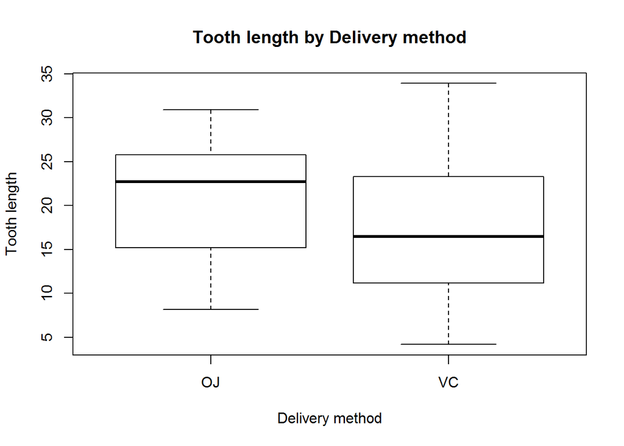

```r
ToothGrowth$dose<-as.factor(ToothGrowth$dose)
plot(len~supp,data=ToothGrowth,xlab="Delivery method", ylab="Tooth length", main="Tooth length by Delivery method")
```

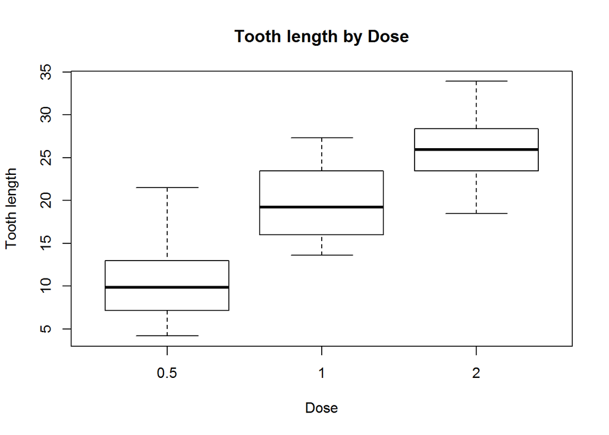

```r
plot(len~dose,data=ToothGrowth,xlab="Dose", ylab="Tooth length", main="Tooth length by Dose")
```

Looking at the graphs, we are interested in testing whether or not the Tooth length for Delivery method OJ is significatively larger than VC. We are performing an independent group t-test for the unequal variance case at 95% conficence level.

```r
x<-subset(ToothGrowth,supp=="OJ",len)
y<-subset(ToothGrowth,supp=="VC",len)
t.test(x,y,alternative="greater")
```

```
##
##  Welch Two Sample t-test
##
## data:  x and y
## t = 1.9153, df = 55.309, p-value = 0.03032
## alternative hypothesis: true difference in means is greater than 0
## 95 percent confidence interval:
##  0.4682687       Inf
## sample estimates:
## mean of x mean of y
##  20.66333  16.96333
```

Since the p-value is smaller than 0.05 we find that Delivery method OJ produces larger tooth length at a significant level.

We can similarly test the differences in dose, particularly Dose 2mg with respect the the other 2 in terms of Tooth length..

```r
x<-subset(ToothGrowth,dose=="0.5",len)
y<-subset(ToothGrowth,dose=="1",len)
z<-subset(ToothGrowth,dose=="2",len)
t.test(z,x,alternative="greater")
```

```
##
##  Welch Two Sample t-test
##
## data:  z and x
## t = 11.799, df = 36.883, p-value = 2.199e-14
## alternative hypothesis: true difference in means is greater than 0
## 95 percent confidence interval:
##  13.27926      Inf
## sample estimates:
## mean of x mean of y
##    26.100    10.605
```

```r
t.test(z,y,alternative="greater")
```

```
##
##  Welch Two Sample t-test
##
## data:  z and y
## t = 4.9005, df = 37.101, p-value = 9.532e-06
## alternative hypothesis: true difference in means is greater than 0
## 95 percent confidence interval:
##  4.17387     Inf
## sample estimates:
## mean of x mean of y
##    26.100    19.735
```

In both cases we find that Dose 2mg is significantly better than Dose 1mg and 0.5mg even if we correct for false discovery rate, due to performing 2 tests on the same dataset.